# Assigment1

Pavel Linder, Nikita Brancatisano

11/6/2019

```
## Package 'GA' version 3.2
```

### What does it mean for a function to be non-convex?

A function is non-convex (or concave) if it is a continuous function whose value at the midpoint of every interval in its domain does not exceed the arithmetic mean of its values at the ends of the interval.

# Task 1: Maximization of a non-convex function.

## 1. Code a method f(x, y) that computes a value z, given an input tuple (x, y).

```r
f <- function(x, y)  {
  z <- ((1 - x)^2) + (exp(1) * (y - (x^2))^2)
}
```

## 2. Code a method that visualizes the Rosenbrock function in 3D

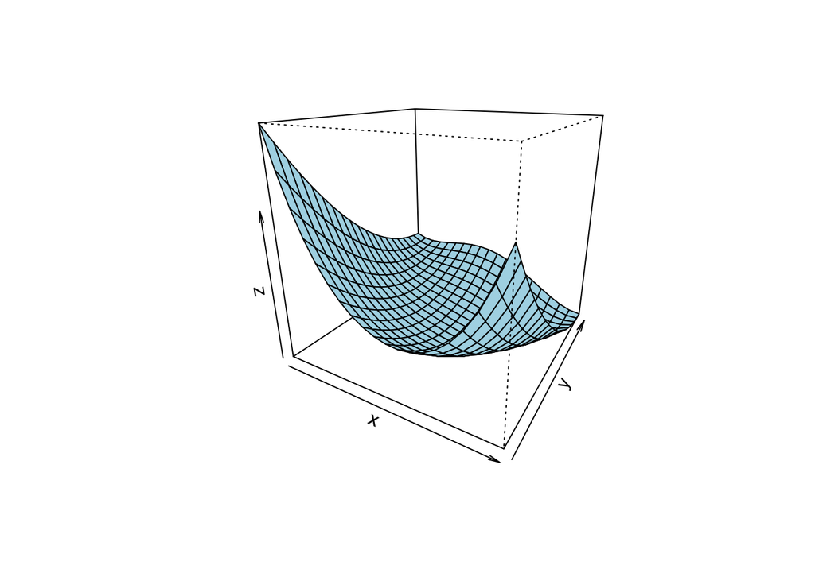

```r
x <- y <- seq(-1, 1, length= 20)
z <- outer(x, y, f)
z[is.na(z)] <- 1 # change non-defined elements to 1
persp(x, y, z, theta = 30, phi = 20, col = "lightblue")
```

## 3. Code a genetic algorithm, that attempts to find the global maximum of this function.

Here, we tried several crossover method and then selected the best one.

```r
#We select a list of crossovers
crossovers = c("ga_spCrossover",
              "gabin_spCrossover", "gabin_uCrossover",
              "gareal_spCrossover", "gareal_waCrossover", "gareal_laCrossover", "gareal_blxCrossover", "gareal_laplaceCrossover",
              "gaperm_cxCrossover", "gaperm_pmxCrossover", "gaperm_pmxCrossover"
        )
```

```r
results = c()
idx <- 0
name <- 0
best <- 0
#We train them all and then we select the best
for (i in 1:length(crossovers)) {
  GA <- ga(type = "real-valued",
           fitness =  function(x) f(x[1], x[2]),
           lower = c(-1, -1), upper = c(1, 1),
           popSize = 50, maxiter = 1000, run = 100,
           crossover = crossovers[i]
           )
  if (best < GA@fitnessValue) {
    idx <- i
    best <- GA@fitnessValue
    bestGA <- GA
  }
  results[i] <- GA@solution
}
```

```r
solution = results[idx]
best_crossover = crossovers[idx]
best_crossover
```

```
## [1] "gareal_laplaceCrossover"
```

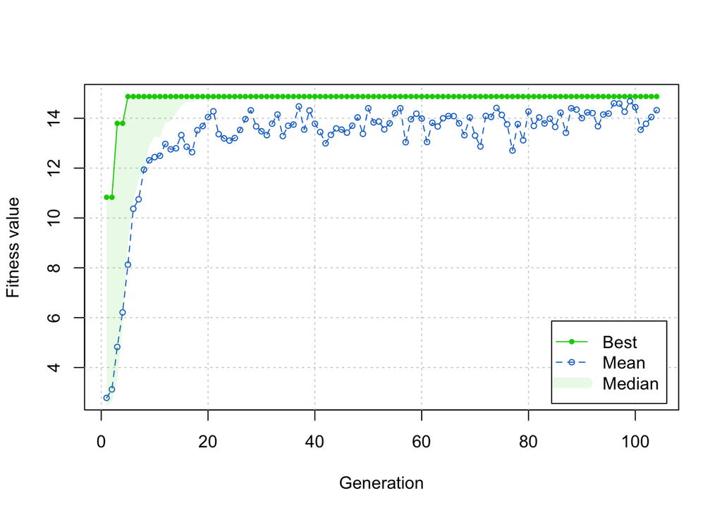

```r
plot(bestGA)
```

```r
summary(bestGA)
```

```
## ── Genetic Algorithm ───────────────────
##
## GA settings:
## Type                  =  real-valued
## Population size       =  50
## Number of generations =  1000
## Elitism               =  2
## Crossover probability =  0.8
## Mutation probability  =  0.1
## Search domain =
##       x1 x2
## lower -1 -1
## upper  1  1
##
## GA results:
## Iterations             = 104
## Fitness function value = 14.87313
## Solution =
##      x1 x2
## [1,] -1 -1
```

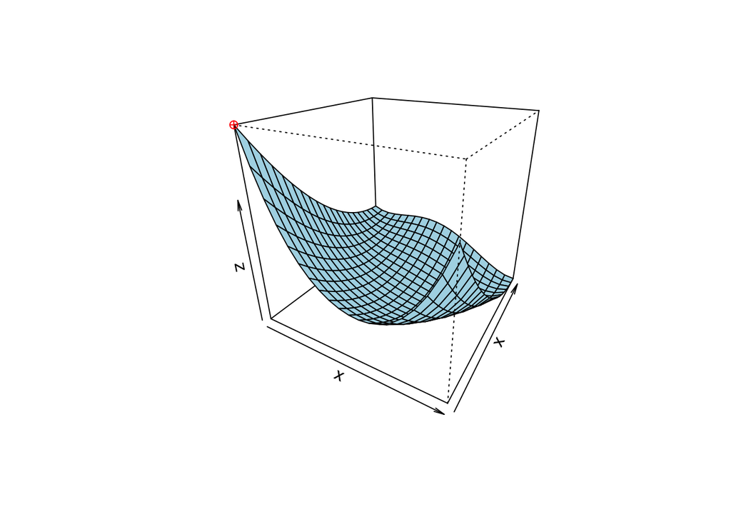

[figure not shown]

```r
max_x = as.vector(bestGA@solution[,1])
max_y = as.vector(bestGA@solution[,2])
max_z = as.vector(f(bestGA@solution[,1], bestGA@solution[,2]))
{res <- persp(x = x, y = x, z = z,theta = 30, phi = 25, col = "lightblue")
points(trans3d(max_x, max_y, max_z, pmat=res), col="red", pch = 10)}
```

## 4. Discuss the results.

### How does performance vary when you are increasing the number of iterations?

The performance is slowed down because the GA reaches the maximum solution before we run all of the iterations, thus increasing the number would only slow down the search without providing any significant benefit.

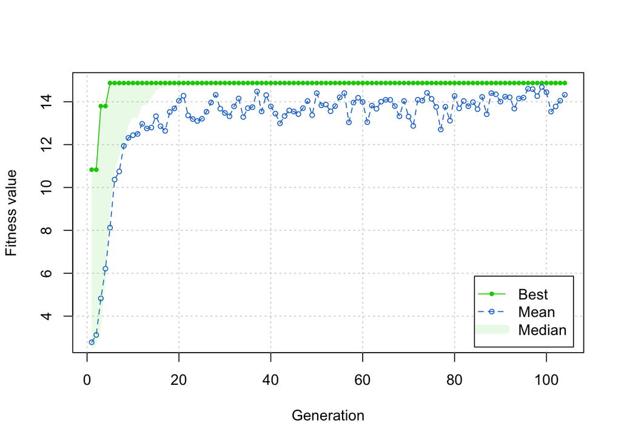

```r
plot(bestGA)
```

### What about population size?

```r
time = c()
size = c()
```

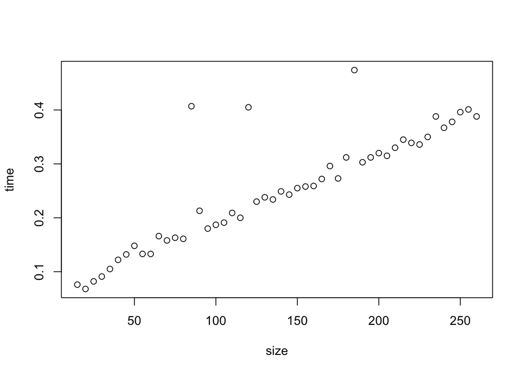

```r
plot(size, time)
```

### Explain the difference between local and global maxima. A local maxima is the biggest element for one given subset of the whole function. There can still be other values greater than this one, outside of the range of the subset. The global maximum is the largest overall value of the function (on the whole domain of the function).